# Intro to R - 4. Base R Plots

OIT/SMU Libraries Data Science Workshop Series

Michael Hahsler

# Simple Plots

# Introduction

- Ploting is an integral part of R.
- R plots on devices (e.g., `X11(), quarz(), windows(), pdf(), png()`)
- Plotting commands are divided into three basic groups:
  1. **High-level plotting functions** create a new plot on the graphics device, possibly with axes, labels, titles and so on.
  2. **Low-level plotting functions** add more information to an existing plot, such as extra points, lines and labels.
  3. **Interactive graphics functions** allow you interactively add information to, or extract information from, an existing plot, using a pointing device such as a mouse.

We will only discuss “base” graphics here. A very popular alternative is `ggplot`.

# High-level Graphics Functions

# plot

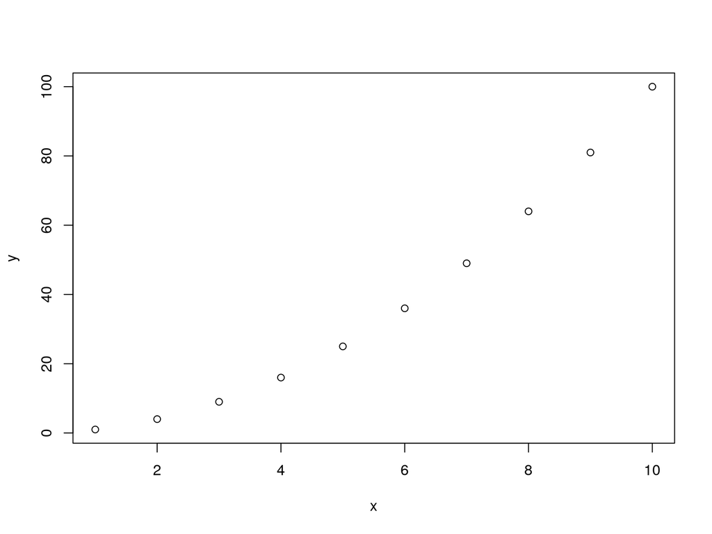

```r
x <- 1:10
y <- x^2
plot(x, y)
```

# plot

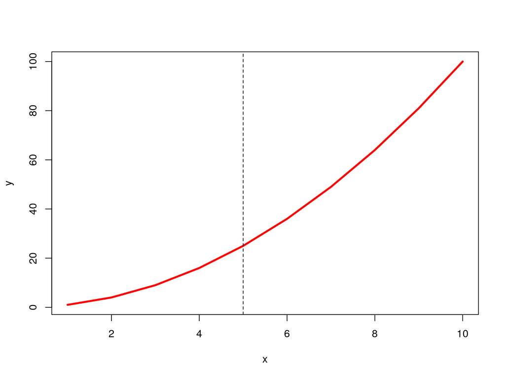

```r
# use type l = line, line width 3 and red
plot(x, y, type = "l", lwd = 3, col = "red")

# add a vertical dashed (line type 2) line
abline(v=5, lty=2)       # add a vertical line
```

## Getting help for plot

`? plot`

Shows that plot is a so called generic function. Generic functions have implementations dor different data types which get “dispatched” at call-time.

`? plot.default`

This is the default function for plot.

`? par`

Graphical parameters which typically can be passed on as `...` to plot.

# Scatterplot

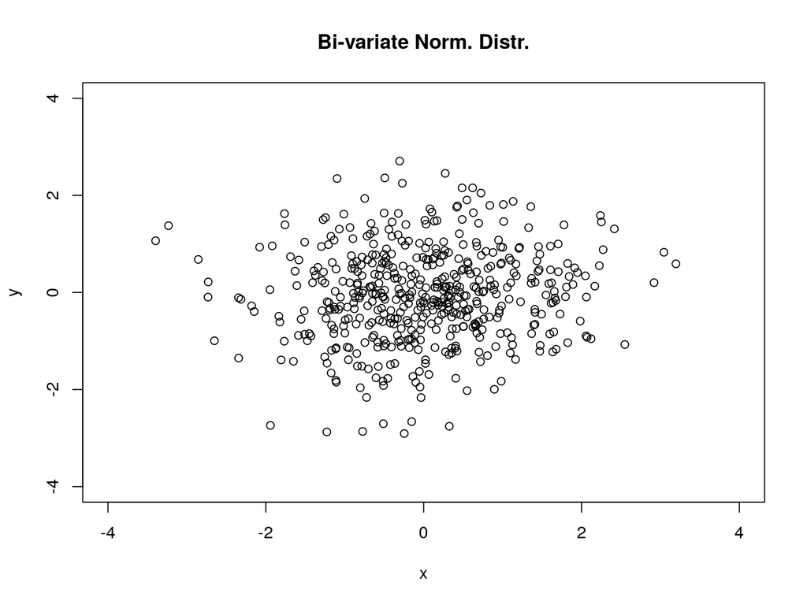

```r
x <- rnorm(500)
y <- rnorm(500)
plot(x, y, main="Bi-variate Norm. Distr.",
  xlim = c(-4,4), ylim = c(-4,4))
```

# Scatterplot matrix (pairs plot)

`plot()` is generic which means that it produces different results depending on the type of data. For example, data frames result in a pairwise scatterplot matrix.

```r
data(iris)
head(iris, n=1)     # iris is a data.frame
```

```
##   Sepal.Length Sepal.Width Petal.Length Petal.Width Species
## 1          5.1         3.5          1.4         0.2  setosa
```

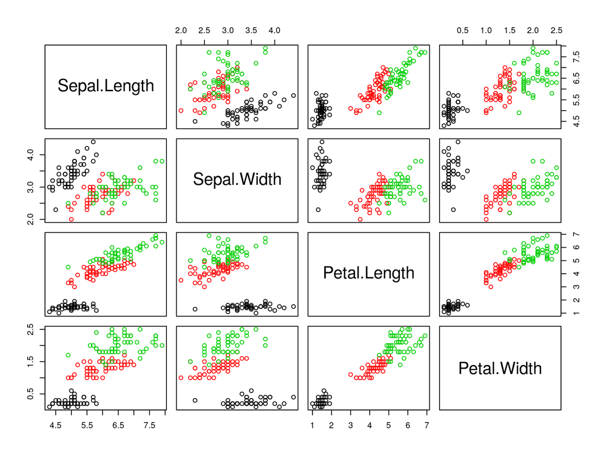

```r
plot(iris[,-5], col= iris[,5]) # use Species (col 5) for color
```

# parplot - Bar Charts

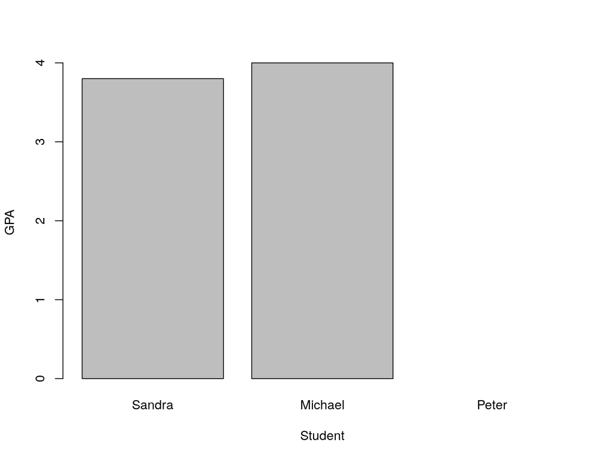

```r
gpa <- c(Sandra = 3.8, Michael = 4.0, Peter = NA)
gpa.sort <- sort(gpa, na.last = TRUE)
barplot(gpa.sort, ylab = "GPA", xlab = "Student")
```

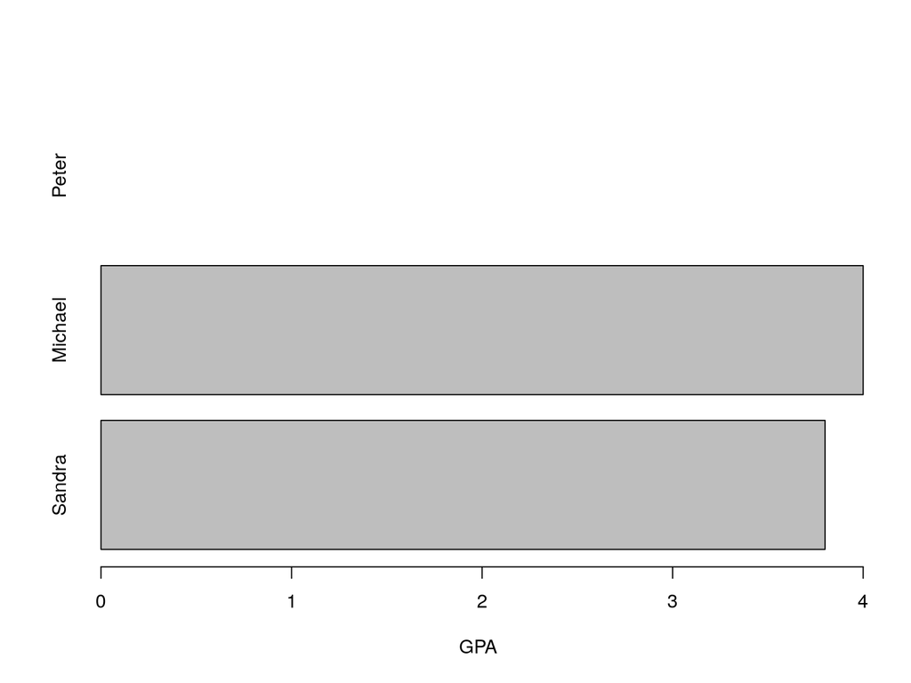

```r
barplot(gpa, xlab = "GPA", horiz = TRUE)
```

# hist - Histogram

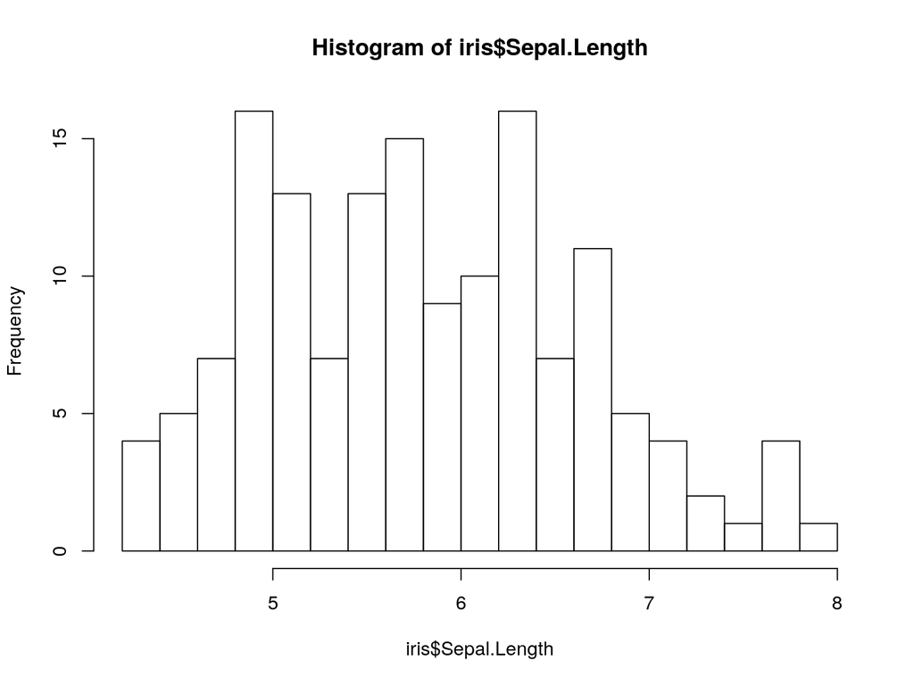

```r
hist(iris$Sepal.Length, breaks=20)
```

# hist - Histogram with estimated density

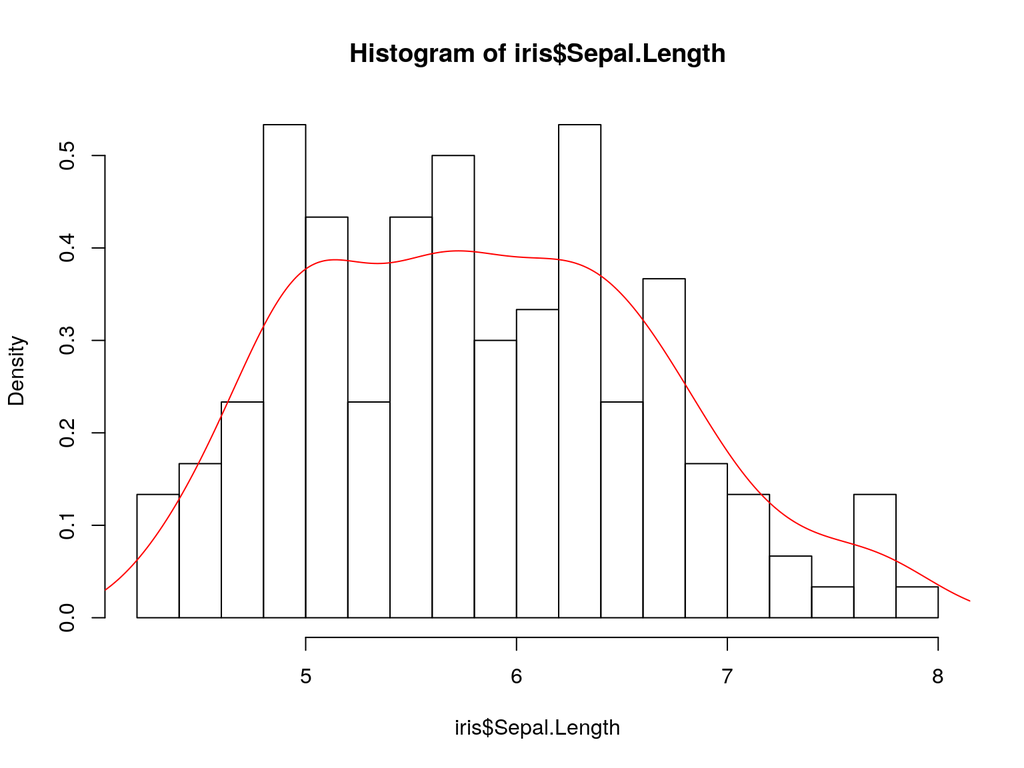

```r
hist(iris$Sepal.Length, breaks=20, prob=TRUE)
lines(density(iris$Sepal.Length), col="red")
```

volcano is a R data set with elevation measurements of Maunga Whau on a 10m by 10m grid.

```r
dim(volcano)
```

```
## [1] 87 61
```

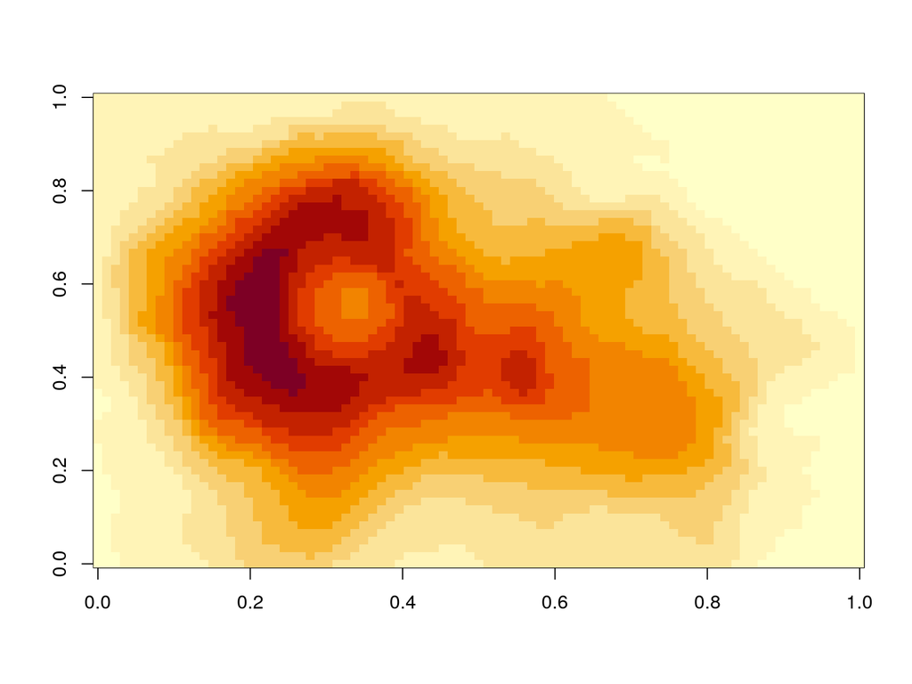

```r
image(volcano)
```

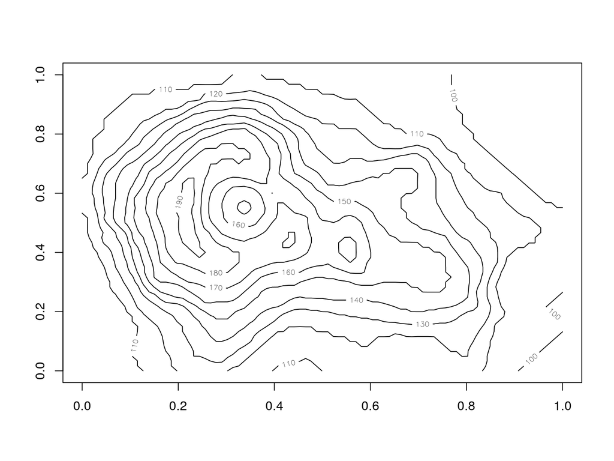

```r
contour(volcano)
```